# Modern concepts and methods in Macroecology and Biogeography

Day 8: Functional biogeography

Pierre Denelle, Holger Kreft & Patrick Weigelt

June 2nd, 2021

*back to overview*

- `FD`
- `dplyr`
- `RColorBrewer`
- `psych`
- `rgdal`
- `rgeos`
- `ade4`
- `gawdis`

If you want to visualize this tutorial in the viewer inside RStudio (to save space on your screen) run the following chunk of code:

```r
install.packages("rstudioapi") # install an R-package required for this step
dir <- tempfile()
dir.create(dir)
download.file("https://gift.uni-goettingen.de/mcmmb/index.html", destfile = file.path(dir, "index.html"))
download.file("https://gift.uni-goettingen.de/mcmmb/Day8.html", destfile = file.path(dir, "Day8.html"))
htmlFile <- file.path(dir, "Day8.html")
rstudioapi::viewer(htmlFile)
```

Now you can conveniently copy code from the viewer into your script.

**Load R packages & island data set**

```r
library(FD) # Functional diversity
library(dplyr) # data.frame operations
library(RColorBrewer) # color gradients
library(psych) # pair plot
library(rgdal) # shapefile
library(rgeos) # grid cells centroids
library(ade4) # Dissimilarity matrix and PCoA
library(gawdis) # Different weights to trais before PCoA
```

# 1. Data

## 1.1. Loading palm distribution data

Data from Kreft, H., Sommer, J.H. & Barthlott, W. (2006).  
The significance of geographic range size for spatial diversity  
patterns in Neotropical palms. *Ecography*, 29, 21-30.

```r
species <- read.csv("data/palms_species_per_gridcell.csv",
                    sep=",", stringsAsFactors = FALSE)
head(species)
```

```
##   grid_id spp_Id    GENUS EPITHET
## 1   13735    550 Ammandra natalia
## 2   13736    550 Ammandra natalia
## 3   13737    550 Ammandra natalia
## 4   13738    550 Ammandra natalia
## 5   13910    550 Ammandra natalia
## 6   13911    550 Ammandra natalia
```

```r
length(unique(species$grid_id)) # number of grid cells
```

```
## [1] 6638
```

```r
# Adding a species column
species$species <- paste(species$GENUS, species$EPITHET, sep = " ")

# Spatial data
# gridcells corresponding to palm distribution data and americas coastline
grid <- readOGR("data/30min_grid_select50/30min_grid_select50%.shp",
                integer64 = "allow.loss")
americas <- readOGR("data/americas/americas.shp")
# remember to include coordinate system
grid@proj4string <- CRS("+proj=longlat +ellps=WGS84 +no_defs")
americas@proj4string <- CRS("+proj=longlat +ellps=WGS84 +no_defs")
# have a look at the grid's attribute table
head(grid@data)
```

```
##    ID AREA PORTION
## 0 538 0.25     100
## 1 539 0.25     100
## 2 540 0.25     100
## 3 712 0.25     100
## 4 713 0.25     100
## 5 714 0.25     100
```

```r
# change clomumn name of first column ('ID')
names(grid@data)[1] <- "grid_id"
head(grid@data)
```

```
##   grid_id AREA PORTION
## 0     538 0.25     100
## 1     539 0.25     100
## 2     540 0.25     100
## 3     712 0.25     100
## 4     713 0.25     100
## 5     714 0.25     100
```

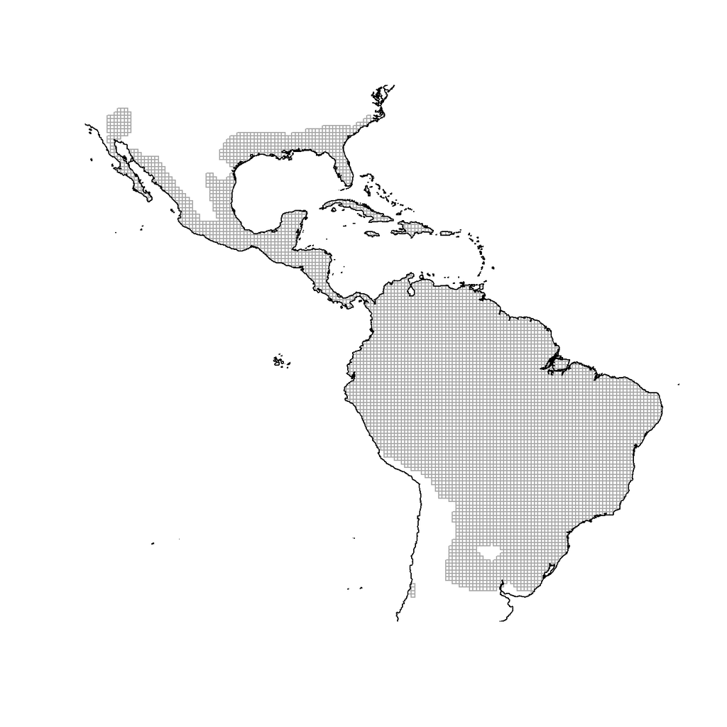

```r
# plot it
plot(grid, border= "darkgrey")
plot(americas, add = TRUE)
```

**Calculate latitude and longitude from the grid’s polygons**

```r
# convert the polygons to points (mass centroids)
grid_centroids <- gCentroid(grid, byid = TRUE)

# extract the coordinates of the points
coordinates <- data.frame(grid_centroids@coords)
head(coordinates)
```

```
##           x     y
## 0 -114.2507 36.25
## 1 -113.7507 36.25
## 2 -113.2507 36.25
## 3 -114.7507 35.75
## 4 -114.2507 35.75
## 5 -113.7507 35.75
```

```r
# add grid_id to coordinates data.frame
coordinates <- data.frame(grid_id = grid@data$grid_id,
                          Long = coordinates$x, Lat = coordinates$y)

# join centroid coordinates to the grid shapefile
grid@data <- left_join(grid@data, coordinates, by = "grid_id")
head(grid@data)
```

```
##   grid_id AREA PORTION      Long   Lat
## 1     538 0.25     100 -114.2507 36.25
## 2     539 0.25     100 -113.7507 36.25
## 3     540 0.25     100 -113.2507 36.25
## 4     712 0.25     100 -114.7507 35.75
## 5     713 0.25     100 -114.2507 35.75
## 6     714 0.25     100 -113.7507 35.75
```

```r
# join centroid coordinates to species data.frame
species <- left_join(species, coordinates, by = "grid_id")
head(species)
```

```
##   grid_id spp_Id    GENUS EPITHET          species      Long   Lat
## 1   13735    550 Ammandra natalia Ammandra natalia -78.25066 -1.25
## 2   13736    550 Ammandra natalia Ammandra natalia -77.75066 -1.25
## 3   13737    550 Ammandra natalia Ammandra natalia -77.25066 -1.25
## 4   13738    550 Ammandra natalia Ammandra natalia -76.75066 -1.25
## 5   13910    550 Ammandra natalia Ammandra natalia -78.25066 -1.75
## 6   13911    550 Ammandra natalia Ammandra natalia -77.75066 -1.75
```

## 1.2. Trait data

Data from Kissling, W. D., Balslev, H., Baker, W. J., Dransfield, J., Göldel, B., Lim, J. Y., Onstein, R. E., & Svenning, J.-C. (2019).  
PalmTraits 1.0, a species-level functional trait database of palms worldwide.  
*Scientific Data*, 6(1), 1–13.

A database of palm traits (Kissling et al. 2019)

PalmTraits 1.0: functional traits for palm species over the world.

```r
# Traits
tra <- read.table("data/palm_traits/PalmTraits_1.0.txt",
                  stringsAsFactors = FALSE, sep= "\t", header = TRUE)
head(tra); dim(tra)
```

```
##                   SpecName       accGenus accSpecies     PalmTribe
## 1   Acanthophoenix crinita Acanthophoenix    crinita       Areceae
## 2 Acanthophoenix rousselii Acanthophoenix  rousselii       Areceae
## 3     Acanthophoenix rubra Acanthophoenix      rubra       Areceae
## 4   Acoelorrhaphe wrightii  Acoelorrhaphe   wrightii Trachycarpeae
## 5       Acrocomia aculeata      Acrocomia   aculeata      Cocoseae
## 6         Acrocomia crispa      Acrocomia     crispa      Cocoseae
##   PalmSubfamily Climbing Acaulescent Erect StemSolitary StemArmed LeavesArmed
## 1    Arecoideae        0           0     1            1         1           1
## 2    Arecoideae        0           0     1            1         1           1
## 3    Arecoideae        0           0     1            1         1           1
## 4  Coryphoideae        0           0     1            0         0           1
## 5    Arecoideae        0           0     1            1         1           1
## 6    Arecoideae        0           0     1            1         1           1
##   MaxStemHeight_m MaxStemDia_cm UnderstoreyCanopy MaxLeafNumber
```

[output cut: 34 more lines]

```
## [1] 2557   29
```

```r
# knitr::kable(tra[1:10, ])
```

Several traits available, before checking them, we merge the trait table with the species data frame.

## 1.2. Merging tables

Merging trait table with spatial gridded dataset.

```r
# Trait coverage
sp_tra <- left_join(species[!duplicated(species$species), ],
                    tra,
                    by = c("species" = "SpecName"))
dim(sp_tra)
```

```
## [1] 550  35
```

```r
head(sp_tra)
```

```
##   grid_id spp_Id       GENUS     EPITHET                 species      Long
## 1   13735    550    Ammandra     natalia        Ammandra natalia -78.25066
## 2   10937    549    Ammandra  decasperma     Ammandra decasperma -77.22739
## 3   12862    548    Ammandra   dasyneura      Ammandra dasyneura -77.25066
## 4   12509    547 Phytelephas    tumacana    Phytelephas tumacana        NA
## 5   13036    546 Phytelephas tenuicaulis Phytelephas tenuicaulis -77.75066
## 6    9882    545 Phytelephas   seemannii   Phytelephas seemannii        NA
##         Lat    accGenus  accSpecies    PalmTribe PalmSubfamily Climbing
## 1 -1.250000        <NA>        <NA>         <NA>          <NA>       NA
## 2  6.769766    Ammandra  decasperma Phytelepheae Ceroxyloideae        0
## 3  1.250000        <NA>        <NA>         <NA>          <NA>       NA
## 4        NA Phytelephas    tumacana Phytelepheae Ceroxyloideae        0
## 5  0.750000 Phytelephas tenuicaulis Phytelepheae Ceroxyloideae        0
## 6        NA Phytelephas   seemannii Phytelepheae Ceroxyloideae        0
##   Acaulescent Erect StemSolitary StemArmed LeavesArmed MaxStemHeight_m
```

[output cut: 41 more lines]

## 1.3. Trait description

Here, we aim at describing several facets of each trait. Specifically, we should look at: - trait type (continuous, ordinal, categorical, binary) - trait coverage (how many species have a trait value) - trait distribution (if too asymmetrical, log-transformation) - trait correlation (are some traits carrying the same information?) - ecological significance (is the trait varying against environment? biotic variable? physiological process?)

### 1.3.1. Life form and habit

Acaulescent ((leaves and inflorescence rise from the ground, i.e. lacking a visible aboveground stem) ), erect or climbing. Binary traits except when one species varies.

StemSolitary (single-stemmed versus clustered)

```r
# Frequency of each category
table(sp_tra$Climbing)
```

```
##
##   0   1   2
## 461   5   1
```

```r
table(sp_tra$Acaulescent)
```

```
##
##   0   1   2
## 414  52   1
```

```r
table(sp_tra$Erect)
```

```
##
##   0   1   2
##  57 408   2
```

```r
# Recoding 2 as 1 (when populations vary in one trait)
# => not enough entries
sp_tra[which(sp_tra$Climbing == 2), "Climbing"] <- 1
sp_tra[which(sp_tra$Acaulescent == 2), "Acaulescent"] <- 1
sp_tra[which(sp_tra$Erect == 2), "Erect"] <- 1

table(sp_tra$Climbing) # very unbalanced
```

```
##
##   0   1
## 461   6
```

```r
table(sp_tra$Acaulescent)
```

```
##
##   0   1
## 414  53
```

```r
table(sp_tra$Erect)
```

```
##
##   0   1
##  57 410
```

```r
# Several life forms possible?
table(sp_tra$Climbing, sp_tra$Acaulescent, sp_tra$Erect)
```

```
## , ,  = 0
##
##
##       0   1
##   0   0  52
##   1   5   0
##
## , ,  = 1
##
##
##       0   1
##   0 408   1
##   1   1   0
```

```r
unique(apply(sp_tra[, c("Climbing", "Acaulescent", "Erect")], 1, sum))
```

```
## [1] NA  1  2
```

```r
# not only 1, it means that some plants have several life forms...
# let's check it out
sp_tra$sum_life_form <- apply(sp_tra[, c("Climbing", "Acaulescent",
                                         "Erect")], 1,
                              sum)
table(sp_tra$sum_life_form)
```

```
##
##   1   2
## 465   2
```

```r
sp_tra[which(sp_tra$sum_life_form == 2),
       c("species", "Climbing", "Acaulescent", "Erect")]
```

```
##                    species Climbing Acaulescent Erect
## 8   Phytelephas macrocarpa        0           1     1
## 420    Chamaedorea elatior        1           0     1
```

```r
# Only two exceptions => let's recode them
# https://www.palmpedia.net/wiki/Chamaedorea_elatior => climbing
sp_tra[which(sp_tra$species == "Chamaedorea elatior"), "Erect"] <- 0
# https://en.wikipedia.org/wiki/Phytelephas_macrocarpa => acaulescent
sp_tra[which(sp_tra$species == "Phytelephas macrocarpa"), "Erect"] <- 0

# Now every species has only one life form
sp_tra$sum_life_form <- apply(sp_tra[, c("Climbing", "Acaulescent",
                                         "Erect")], 1,
                              sum)
table(sp_tra$sum_life_form)
```

```
##
##   1
## 467
```

```r
# We can now recode the whole life form as one categorical trait
sp_tra$life_form <- ifelse(sp_tra$Climbing > 0, "Climbing",
                           ifelse(sp_tra$Acaulescent > 0, "Acaulescent",
                                  "Erect"))
table(sp_tra$life_form)
```

```
##
## Acaulescent    Climbing       Erect
##          53           6         408
```

```r
# very unbalanced: few climbing species
```

### 1.3.2. Armature

Whether bearing some form of spines at the stem or not, or both if populations vary in this trait. Whether bearing some form of spines on the leaves or not, or both if populations vary in this trait.

```r
# http://idtools.org/id/palms/palmid/gallery.php
table(sp_tra$StemArmed); table(sp_tra$LeavesArmed)
```

```
##
##   0   1
## 389  74
```

```
##
##   0   1
## 337 130
```

```r
table(sp_tra$StemArmed, sp_tra$LeavesArmed)
```

```
##
##       0   1
##   0 333  56
##   1   4  70
```

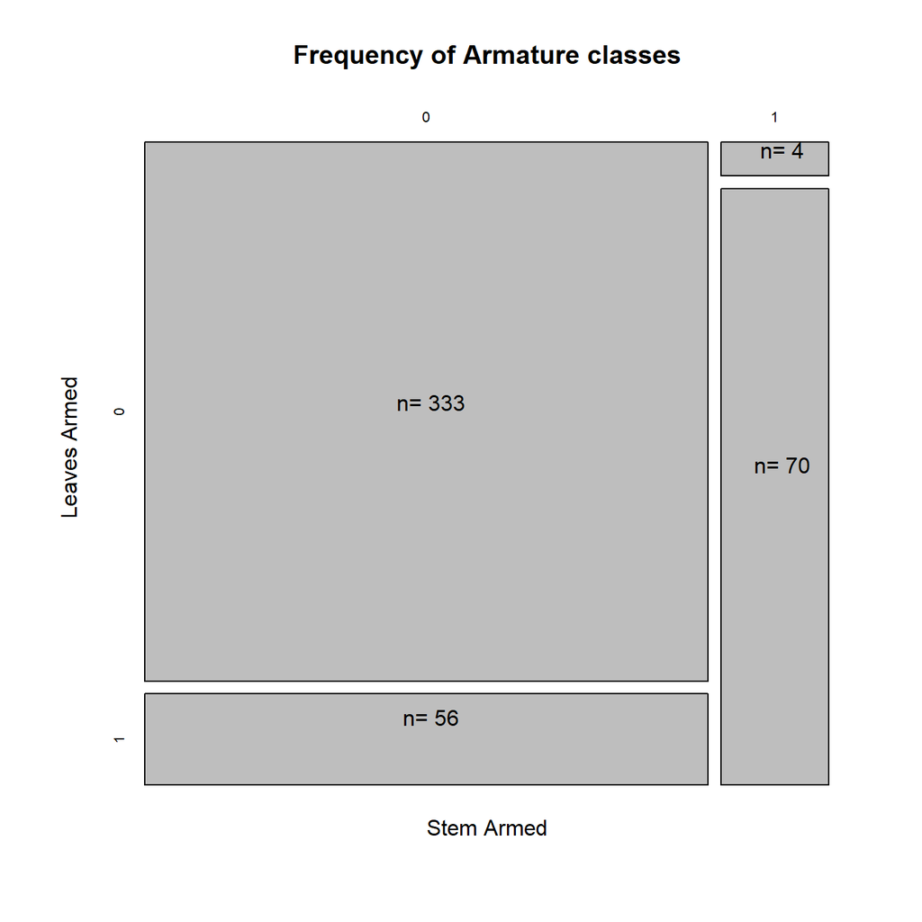

```r
# Plot
plot(table(sp_tra$StemArmed, sp_tra$LeavesArmed),
     main = "Frequency of Armature classes",
     xlab = "Stem Armed", ylab = "Leaves Armed")

prpX <- prop.table(table(sp_tra$StemArmed))
prpY <- prop.table(table(sp_tra$StemArmed, sp_tra$LeavesArmed), margin = 1)
text(prpX/2 * c(1,-1) + 0:1,
     prpY/2 * c(-1,-1,1,1) + c(1,1,0,0),
     paste("n=", table(sp_tra$StemArmed, sp_tra$LeavesArmed)))
```

```r
# Species examples
head(sp_tra[which(sp_tra$LeavesArmed == 0 &
                    sp_tra$StemArmed == 0), "species"])
```

```
## [1] "Ammandra decasperma"     "Phytelephas tumacana"
## [3] "Phytelephas tenuicaulis" "Phytelephas seemannii"
## [5] "Phytelephas schottii"    "Phytelephas macrocarpa"
```

```r
# https://en.wikipedia.org/wiki/Coconut#/media/File:Lefaga,_Return_to_Paradise_beach,_south_coast_Upolu_Island,_Samoa,_2009.jpg
# Cocos nucifera

# http://palmpedia.net/wiki/Mauritiella_armata (leaves not armed, stem yes)

# View(sp_tra[which(sp_tra$LeavesArmed == 1 &
#                     sp_tra$StemArmed == 1), "SpecName"])
```

### 1.3.3. Stem size

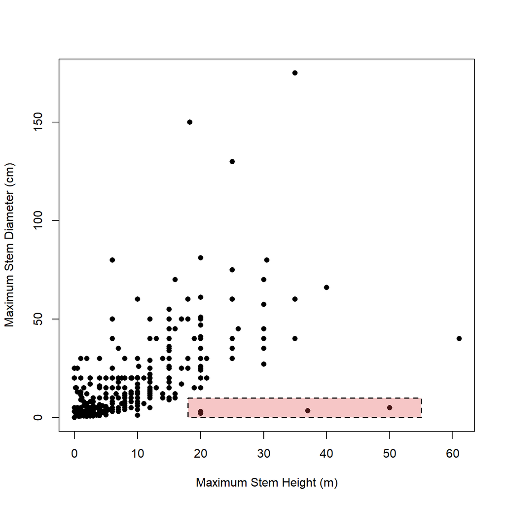

```r
# Plot
plot(sp_tra$MaxStemHeight_m, sp_tra$MaxStemDia_cm, pch = 16,
     xlab = "Maximum Stem Height (m)",
     ylab = "Maximum Stem Diameter (cm)")
rect(xleft = 18, xright = 55, ybottom = 0, ytop = 10,
     lwd = 1.5, lty = 2, add = TRUE, col = "#e3484850")# "firebrick3")
```

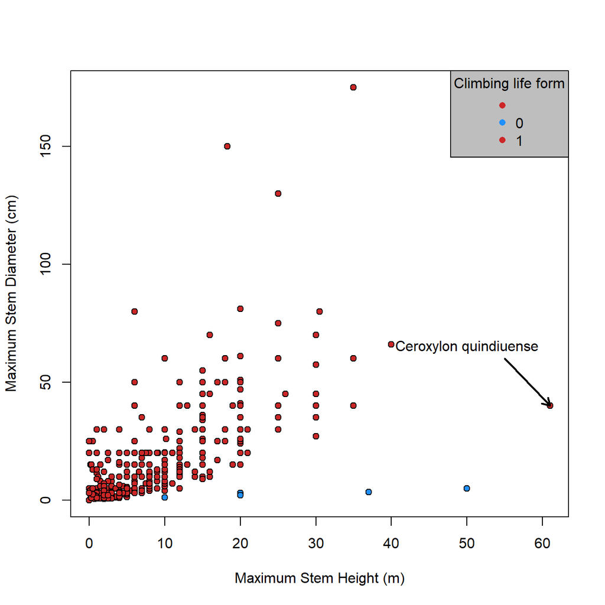

```r
# Create color column based on Climbing life form
sp_tra$col <- c("firebrick3", "dodgerblue")[
  as.numeric(cut(sp_tra$Climbing, breaks = 2))]

plot(sp_tra$MaxStemHeight_m, sp_tra$MaxStemDia_cm,
     bg = sp_tra$col, pch = 21, col = "black",
     xlab = "Maximum Stem Height (m)",
     ylab = "Maximum Stem Diameter (cm)")
legend("topright", title = "Climbing life form", bg = "grey",
       legend = unique(sp_tra$Climbing),
       col = c("firebrick3", "dodgerblue"),
       pch = 16)
text(50, 65, labels = "Ceroxylon quindiuense")
arrows(x0 = 55, x1 = 61, y0 = 60, y1 = 40,
       length = 0.1, lwd = 2)
```

```r
# UnderstoreyCanopy
# table(sp_tra$UnderstoreyCanopy, sp_tra$Acaulescent)
# boxplot(sp_tra$MaxStemHeight_m ~ sp_tra$UnderstoreyCanopy)
# We won't use this sp_trait
```

[figure not shown]

Ceroxylon quindiuense

The world’s tallest monocotyledon.

### 1.3.4. Leaf

Many leaf traits available, let’s make a pair plot to have a quick look at their correlations.

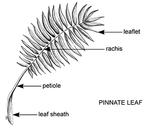

Palm leaf

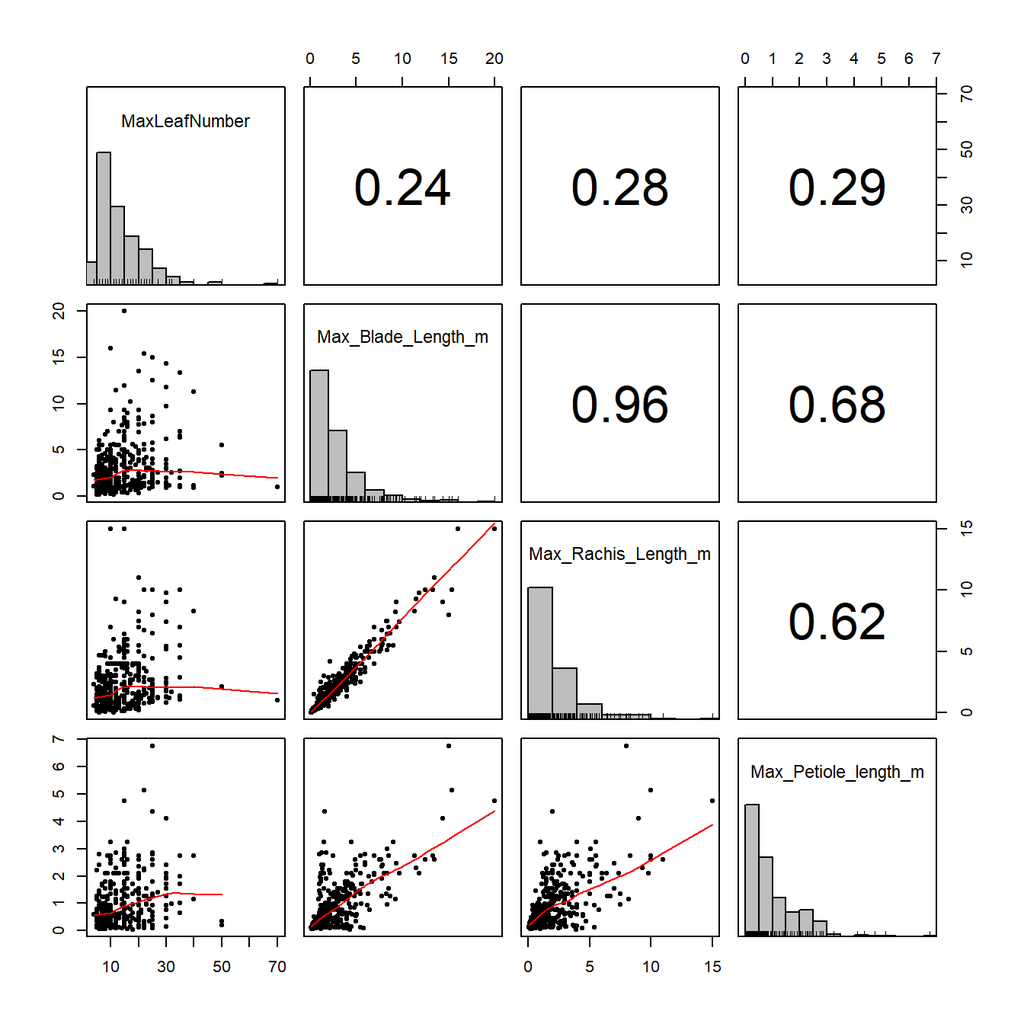

```r
# Pair plot
pairs.panels(sp_tra[, c("MaxLeafNumber", "Max_Blade_Length_m",
                        "Max_Rachis_Length_m", "Max_Petiole_length_m")],
             density = FALSE, ellipses = FALSE, hist.col = "grey")
```

Some leaf traits are highly correlated.

### 1.3.5. Fruit

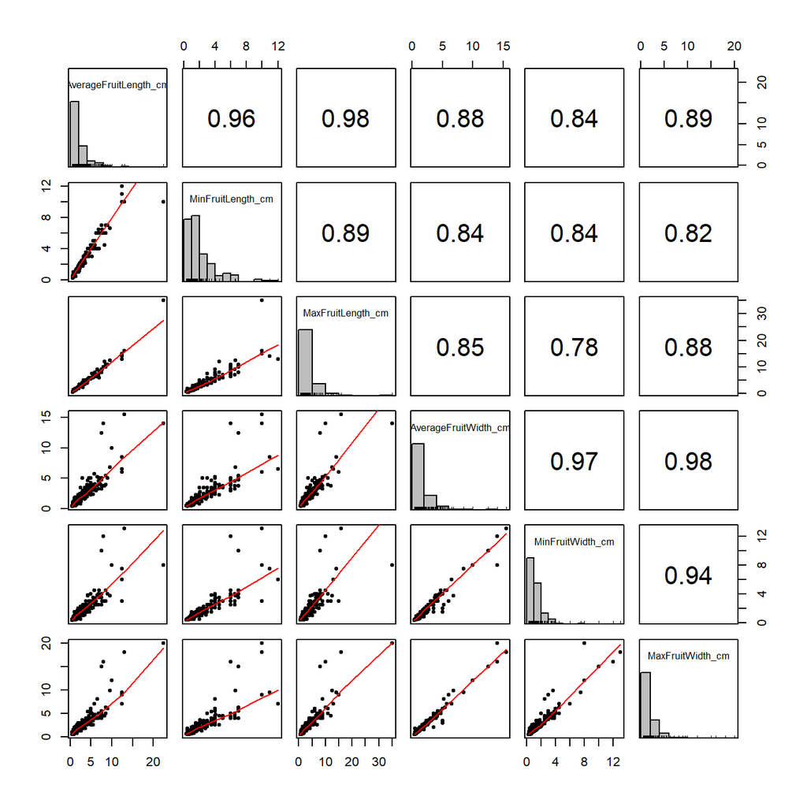

```r
# Pair plot
pairs.panels(sp_tra[, c("AverageFruitLength_cm", "MinFruitLength_cm",
                        "MaxFruitLength_cm", "AverageFruitWidth_cm",
                        "MinFruitWidth_cm", "MaxFruitWidth_cm")],
             density = FALSE, ellipses = FALSE, hist.col = "grey")
```

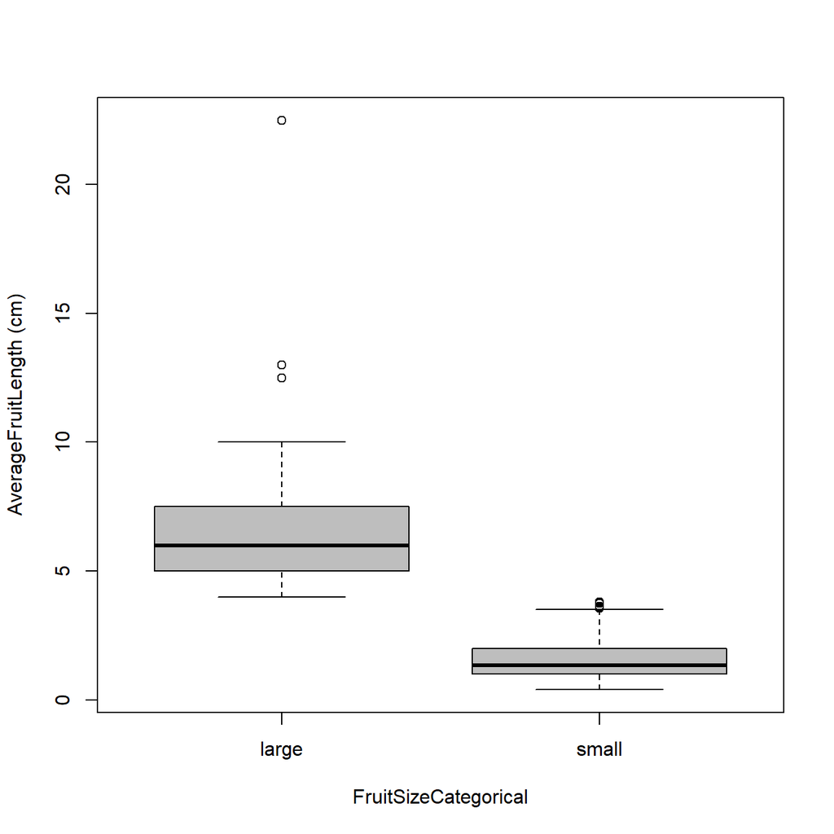

```r
# All traits correlated, we'll take only AverageFruitLength_cm

# Also some categorical traits
boxplot(sp_tra$AverageFruitLength_cm ~ sp_tra$FruitSizeCategorical,
        col = "grey",
        xlab = "FruitSizeCategorical", ylab = "AverageFruitLength (cm)")
```

```r
table(sp_tra$FruitShape)
```

```
##
##           ellipsoid  elongate   globose     ovoid pyramidal
##       118         8        25       130       183         3
```

```r
# too detailed and not complete

# table(sp_tra$FruitColorDescription)
# table(sp_tra$MainFruitColors)
table(sp_tra$Conspicuousness) # summarises colors
```

```
##
##             conspicuous     cryptic
##          24         130         313
```

```r
# https://www.monaconatureencyclopedia.com/metroxylon-amicarum/?lang=en
```

## 1.4. Traits selected

Based on the different trait properties we just observed, we can come with a subset of relevant traits to keep.

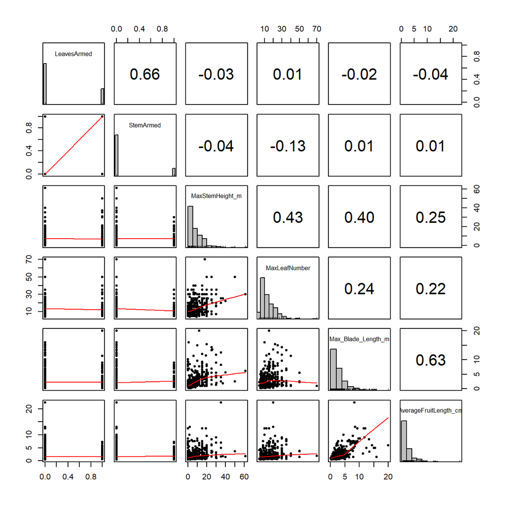

```r
tra_select <- c("life_form", "LeavesArmed", "StemArmed",
                "MaxStemHeight_m", "MaxLeafNumber", "Max_Blade_Length_m",
                "AverageFruitLength_cm")

# Only columns of interest
sp_tra <- sp_tra[, c("species", tra_select)]

# Distribution of continuous traits
pairs.panels(sp_tra[, c("LeavesArmed", "StemArmed",
                        "MaxStemHeight_m", "MaxLeafNumber",
                        "Max_Blade_Length_m", "AverageFruitLength_cm")],
             density = FALSE, ellipses = FALSE, hist.col = "grey")
```

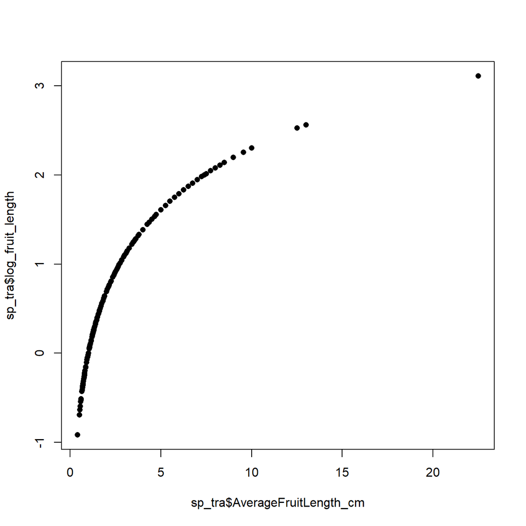

```r
# Log-transforming all the continuous traits
sp_tra$log_height <- log(sp_tra$MaxStemHeight_m + 1)
sp_tra$log_leaf_nb <- log(sp_tra$MaxLeafNumber)
sp_tra$log_blade <- log(sp_tra$Max_Blade_Length_m)
sp_tra$log_fruit_length <- log(sp_tra$AverageFruitLength_cm)

# Plot
plot(sp_tra$AverageFruitLength_cm, sp_tra$log_fruit_length, pch = 16)
```

```r
# Change vector of traits of interest
tra_select <- c("life_form", "LeavesArmed", "StemArmed", "log_height",
                "log_leaf_nb", "log_blade", "log_fruit_length")
```

# 2. Trait maps

## 2.1. Trait distribution

MaxStemHeight_m as an example.

```r
# Map of trait coverage: MaxStemHeight_m
# Add the trait coverage to grid spatialpolygondataframe
species_height <- left_join(
  species[, c("grid_id", "species", "Long", "Lat")],
  sp_tra[, c("species", "MaxStemHeight_m")],
  by = "species")
head(species_height)
```

```
##   grid_id          species      Long   Lat MaxStemHeight_m
## 1   13735 Ammandra natalia -78.25066 -1.25              NA
## 2   13736 Ammandra natalia -77.75066 -1.25              NA
## 3   13737 Ammandra natalia -77.25066 -1.25              NA
## 4   13738 Ammandra natalia -76.75066 -1.25              NA
## 5   13910 Ammandra natalia -78.25066 -1.75              NA
## 6   13911 Ammandra natalia -77.75066 -1.75              NA
```

```r
# tapply function
head(tapply(species_height$MaxStemHeight_m,
            species_height$grid_id,
            function(x) mean(x, na.rm = TRUE)))
```

```
##  538  539  540  712  713  714
## 18.3 18.3 18.3 18.3 18.3 18.3
```

```r
grid_mean_height <- tapply(species_height$MaxStemHeight_m,
                           species_height$grid_id,
                           function(x) mean(x, na.rm = TRUE))
grid_mean_height <- data.frame(
  grid_id = names(grid_mean_height),
  mean_height = as.numeric(grid_mean_height))

# Plot
str(grid_mean_height$grid_id); str(grid@data$grid_id)
```

```
##  Factor w/ 6638 levels "10048","10049",..: 5815 5816 5817 6218 6219 6220 6221 6222 6451 6454 ...
```

[output not shown]

```r
grid_mean_height$grid_id <- as.numeric(as.character(grid_mean_height$grid_id))
grid@data <- left_join(grid@data, grid_mean_height, by = "grid_id")

# Make a color ramp
col_func <- colorRampPalette(c("olivedrab1", "olivedrab4"))
col_func(10)
```

```
##  [1] "#C0FF3E" "#B6F23A" "#ACE537" "#A3D834" "#99CB31" "#8FBE2E" "#86B12B"
##  [8] "#7CA428" "#729725" "#698B22"
```

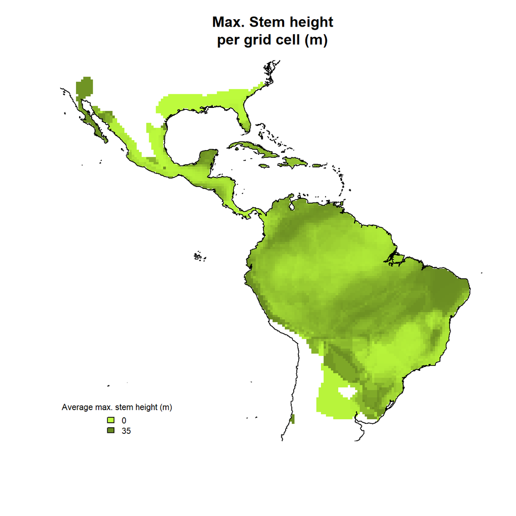

```r
my_col <- col_func(length(unique(grid@data$mean_height)))

# Rank variable for color assignment
grid@data$order <- findInterval(grid@data$mean_height,
                                sort(grid@data$mean_height))

# Plot of height distribution
plot(grid, col = col_func(nrow(grid@data))[grid@data$order],
     border = NA,
     main = "Max. Stem height\nper grid cell (m)")
plot(americas, add = TRUE)

legend("bottomleft", # position
       legend = range(grid@data$mean_height, na.rm = TRUE),
       title = "Average max. stem height (m)",
       fill = col_func(2),
       cex = 0.7,
       bty = "n") # no box around it
```

## 2.2. Trait coverage

We also saw that not all species have a trait value. We therefore need to make a trait coverage assessment.

```r
head(tapply(species_height$MaxStemHeight_m,
            species_height$grid_id,
            function(x) sum(is.na(x))/length(x)))
```

```
## 538 539 540 712 713 714
##   0   0   0   0   0   0
```

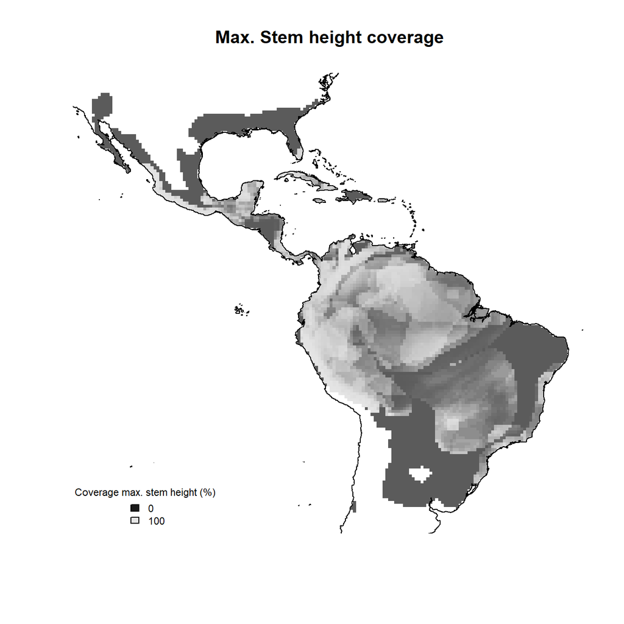

```r
grid_coverage_height <- tapply(species_height$MaxStemHeight_m,
                               species_height$grid_id,
                               function(x) sum(is.na(x))/length(x))
grid_coverage_height <- data.frame(
  grid_id = names(grid_coverage_height),
  coverage_height = as.numeric(grid_coverage_height))

# Conversion to percentages
grid_coverage_height$coverage_height <- 100 *
  grid_coverage_height$coverage_height

# Make a color ramp
col_cov <- colorRampPalette(c("grey10", "grey90"))

# Plot
grid_coverage_height$grid_id <- as.numeric(as.character(grid_coverage_height$grid_id))
grid@data <- left_join(grid@data, grid_coverage_height, by = "grid_id")

# Rank variable for color assignment
grid@data$order_cov <- findInterval(grid@data$coverage_height,
                                    sort(grid@data$coverage_height))

# Plot of height distribution
plot(grid, col = col_cov(nrow(grid@data))[grid@data$order_cov],
     border = NA,
     main = "Max. Stem height coverage")
plot(americas, add = TRUE)

legend("bottomleft", # position
       legend = range(grid@data$coverage_height, na.rm = TRUE),
       title = "Coverage max. stem height (%)",
       fill = col_cov(2),
       cex = 0.7,
       bty = "n") # no box around it
```

# 3. Trait space

The main objective here is to reduce dimensionality, in order to get the main axes of variation between species.

## 3.1. Distances

First step is to compute a distance matrix.

If you had only numerical traits, you could use the Euclidean distances. If doing so, it would be similar to a PCA.

Now, because we also have categorical traits, we cannot simply use the Euclidean distances and we need a way to combine several types of data.

For this, we’ll use the Gower’s distance implemented in the `dist.ktab` function.

```r
# Making a trait table without NAs
tra_select
```

```
## [1] "life_form"        "LeavesArmed"      "StemArmed"        "log_height"
## [5] "log_leaf_nb"      "log_blade"        "log_fruit_length"
```

```r
sp_tra_complete <- sp_tra[, tra_select]
rownames(sp_tra_complete) <- sp_tra$species
sp_tra_complete <- sp_tra_complete[complete.cases(sp_tra_complete), ]
dim(sp_tra_complete); head(sp_tra_complete)
```

```
## [1] 417   7
```

```
##                             life_form LeavesArmed StemArmed log_height
## Ammandra decasperma       Acaulescent           0         0  0.9162907
## Phytelephas tumacana            Erect           0         0  1.7917595
## Phytelephas tenuicaulis         Erect           0         0  2.0794415
## Phytelephas seemannii           Erect           0         0  1.6094379
## Phytelephas macrocarpa    Acaulescent           0         0  1.0986123
## Phytelephas aequatorialis       Erect           0         0  2.7725887
##                           log_leaf_nb log_blade log_fruit_length
## Ammandra decasperma          2.302585  1.504077         2.302585
## Phytelephas tumacana         2.708050  1.791759         2.014903
## Phytelephas tenuicaulis      2.995732  2.048982         2.014903
## Phytelephas seemannii        3.555348  1.871802         2.079442
## Phytelephas macrocarpa       2.995732  2.140066         2.564949
## Phytelephas aequatorialis    3.218876  2.079442         2.014903
```

```r
# Gower distance
?dist.ktab
```

```
## starting httpd help server ... done
```

```r
ktab1 <- ktab.list.df(list(sp_tra_complete[, 1, drop = FALSE],
                           sp_tra_complete[, c(2:3)],
                           sp_tra_complete[, c(4:7)]))

mat_dissim <- dist.ktab(ktab1, type = c("N", "D", "Q"),
                        option = "scaledBYrange") # scaled quantitative traits
head(mat_dissim)
```

```
## [1] 0.4634030 0.4808136 0.4957112 0.1282095 0.5146035 0.5662872
```

```r
all.equal(length(mat_dissim),
          ((nrow(sp_tra_complete)*(nrow(sp_tra_complete)-1))/2))
```

```
## [1] TRUE
```

## 3.2. Principal Coordinate Analysis (PCoA)

PCoA relies on the distances between samples. Therefore, the first step of a PCoA is the construction of a (dis)similarity matrix. While PCA is based on Euclidean distances, PCoA can handle (dis)similarity matrices calculated from quantitative, semi-quantitative, qualitative, and mixed variables.

As always, the choice of (dis)similarity measure is critical and must be suitable to the data in question. For abundance data, Bray-Curtis distance is often recommended. You can use Jaccard index for presence/absence data. When the distance metric is Euclidean, PCoA is equivalent to PCA.

```r
# ape::pcoa() # other option
pcoa_palm <- dudi.pco(mat_dissim, scannf = FALSE, nf = 6)
```

**Coordinates**

```r
# Coordinates of the individuals
# knitr::kable(pcoa_palm$li)

# Coordinates of the variables
# knitr::kable(pcoa_palm$co)
```

**Merging coordinates with trait table and plot**

```r
coord_sp_pcoa <- pcoa_palm$li[, 1:2]
coord_sp_pcoa$sp <- rownames(coord_sp_pcoa)
head(coord_sp_pcoa)
```

```
##                                    A1          A2                        sp
## Ammandra decasperma       -0.08043091 -0.38024551       Ammandra decasperma
## Phytelephas tumacana      -0.11526825  0.05984553      Phytelephas tumacana
## Phytelephas tenuicaulis   -0.11186743  0.08193778   Phytelephas tenuicaulis
## Phytelephas seemannii     -0.10812320  0.06570489     Phytelephas seemannii
## Phytelephas macrocarpa    -0.07203133 -0.35444359    Phytelephas macrocarpa
## Phytelephas aequatorialis -0.10704338  0.12270309 Phytelephas aequatorialis
```

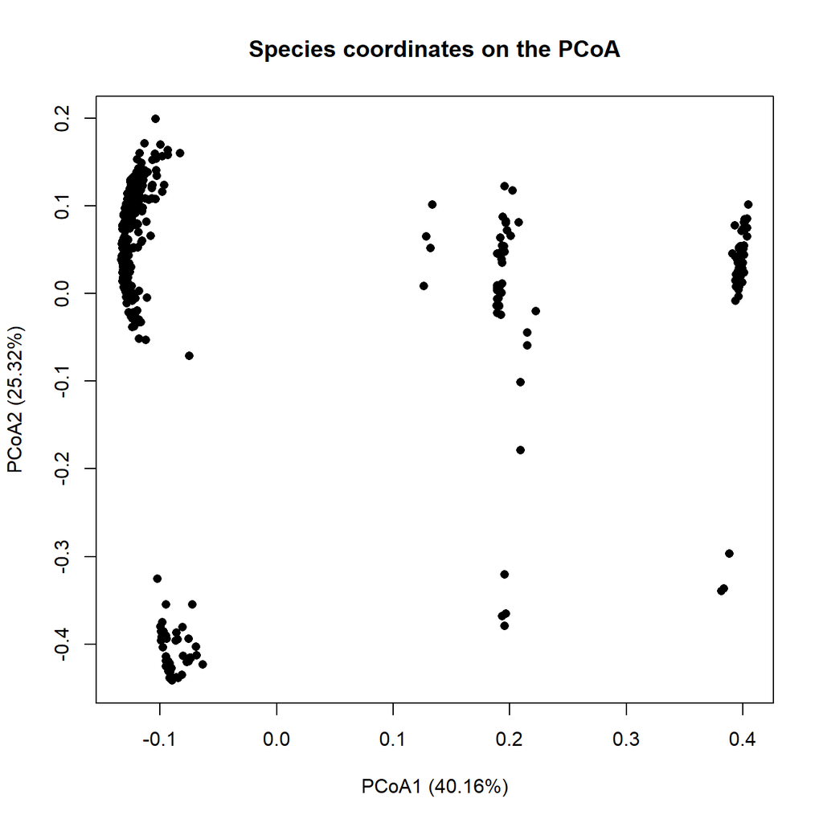

```r
# Merge back PCoA coordinates to complete trait table
sp_tra_complete$sp <- rownames(sp_tra_complete)
sp_tra_complete <- left_join(sp_tra_complete, coord_sp_pcoa, by = "sp")

# Plot
plot(sp_tra_complete$A1, sp_tra_complete$A2, pch = 16,
     main = "Species coordinates on the PCoA",
     xlab = paste0("PCoA1 (",
                   round((pcoa_palm$eig / sum(pcoa_palm$eig))*100, 2)[1],
                   "%)"),
     ylab = paste0("PCoA2 (",
                   round((pcoa_palm$eig / sum(pcoa_palm$eig))*100, 2)[2],
                   "%)"))
```

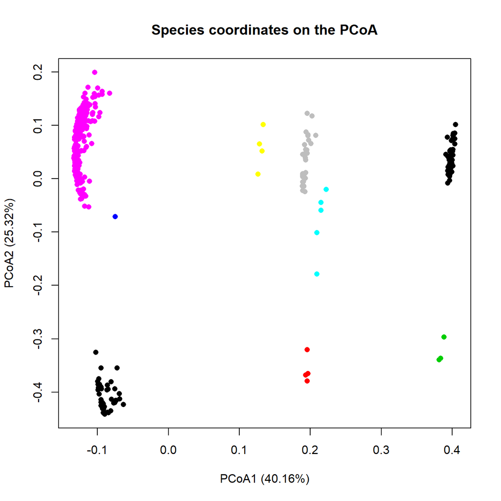

```r
# Adding one column with all binary combinations
sp_tra_complete$cat_comb <- paste(sp_tra_complete$life_form,
                                  sp_tra_complete$LeavesArmed,
                                  sp_tra_complete$StemArmed, sep = "_")

plot(sp_tra_complete$A1, sp_tra_complete$A2, pch = 16,
     col = factor(sp_tra_complete$cat_comb),
     main = "Species coordinates on the PCoA",
     xlab = paste0("PCoA1 (",
                   round((pcoa_palm$eig / sum(pcoa_palm$eig))*100, 2)[1],
                   "%)"),
     ylab = paste0("PCoA2 (",
                   round((pcoa_palm$eig / sum(pcoa_palm$eig))*100, 2)[2],
                   "%)"))
```

```r
# Plot of variables
ordiplot(pcoa_palm)

ef <- envfit(pcoa_palm,
             sp_tra_complete[, tra_select],
             permu = 999)
ef
```

```
##
## ***VECTORS
##
##                        A1       A2     r2 Pr(>r)
## LeavesArmed       0.99944  0.03360 0.9186  0.001 ***
## StemArmed         0.99512  0.09865 0.7663  0.001 ***
## log_height        0.02648  0.99965 0.6090  0.001 ***
## log_leaf_nb      -0.16327  0.98658 0.0464  0.001 ***
## log_blade         0.42484  0.90527 0.0338  0.003 **
## log_fruit_length  0.80583 -0.59214 0.0069  0.252
## ---
## Signif. codes:  0 '***' 0.001 '**' 0.01 '*' 0.05 '.' 0.1 ' ' 1
## Permutation: free
## Number of permutations: 999
##
## ***FACTORS:
##
## Centroids:
##                           A1      A2
## life_formAcaulescent -0.0387 -0.3990
## life_formClimbing     0.1659 -0.0793
## life_formErect        0.0028  0.0591
##
## Goodness of fit:
##               r2 Pr(>r)
## life_form 0.3602  0.001 ***
## ---
## Signif. codes:  0 '***' 0.001 '**' 0.01 '*' 0.05 '.' 0.1 ' ' 1
## Permutation: free
## Number of permutations: 999
```

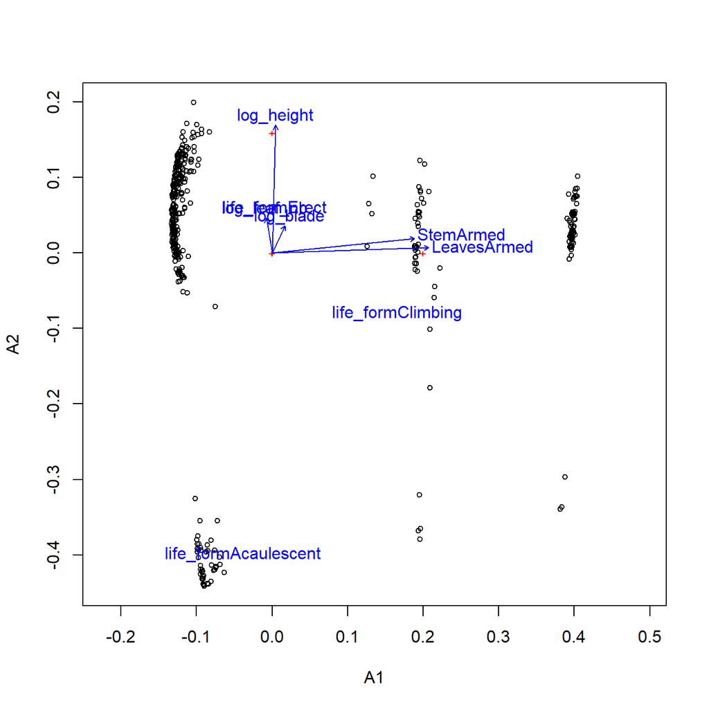

```r
plot(ef, p.max = 0.1)
```